# analiza_obrazow

## Biblioteki

```python
import os
import json
import random
import inspect
from collections import Counter

import numpy as np
import matplotlib.pyplot as plt

import tensorflow as tf
from tensorflow.keras import layers, models
from sklearn.model_selection import train_test_split
from sklearn.metrics import accuracy_score, precision_score, recall_score, f1_score
from perceptron import *
import seaborn as sns
from matplotlib.gridspec import GridSpec
from mpl_toolkits.mplot3d import Axes3D
from collections import Counter
```

## Inicjalizacja deterministycznych ziaren losowych

```python
BASE_SEED = 42
random.seed(BASE_SEED)
np.random.seed(BASE_SEED)
tf.keras.utils.set_random_seed(BASE_SEED)
```

## Wczytanie zbioru Fashion-MNIST

```python
(x_train_full, y_train_full), (x_test, y_test) = tf.keras.datasets.fashion_mnist.load_data()
```

## Podstawowe informacje

```python
print("Train shape:", x_train_full.shape)
print("Test shape:", x_test.shape)
print("Liczba klas:", len(np.unique(y_train_full)))
```

```
Train shape: (60000, 28, 28)
Test shape: (10000, 28, 28)
Liczba klas: 10
```

Zbiór treningowy zawiera 60 000 obrazów 28×28, a testowy 10 000. Dane obejmują 10 klas elementów odzieży.

## Statystyki pikseli

```python
print("\nStatystyki pikseli:")
print("Min:", x_train_full.min())
print("Max:", x_train_full.max())
print("Mean:", x_train_full.mean())
print("Std:", x_train_full.std())
```

```
Statystyki pikseli:
Min: 0
Max: 255
Mean: 72.94035223214286
Std: 90.02118235130526
```

Piksele wahają się od 0 (czarne) do 255 (białe). Średnia ok. 73 przy dużym odchyleniu (90) oznacza, że obrazy są raczej ciemne, ale mocno zróżnicowane - jedne bardzo jasne, inne bardzo ciemne.

## Siatka przykładowych obrazów

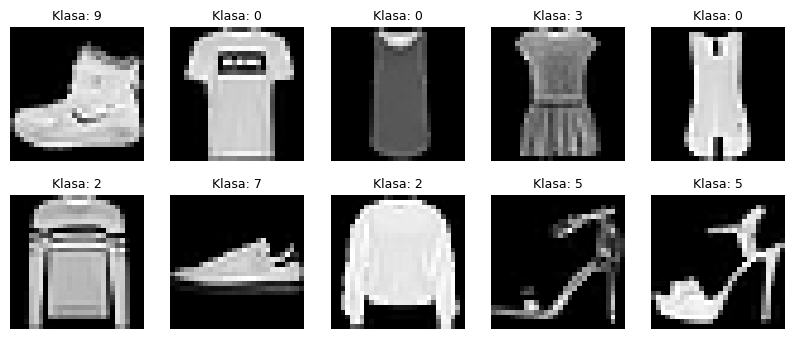

```python
plt.figure(figsize=(10, 4))
for i in range(10):
    plt.subplot(2, 5, i + 1)
    plt.imshow(x_train_full[i], cmap='gray')
    plt.title(f"Klasa: {y_train_full[i]}", fontsize = 9)
    plt.axis('off')
plt.show()
```

## Histogram intensywności pikseli

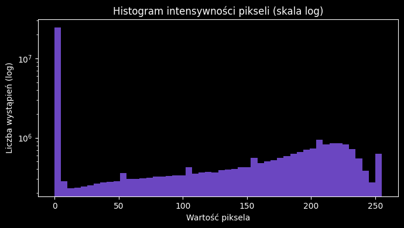

```python
COLORS = {
    'primary': '#6B46C1',
    'secondary': '#9333EA',
    'accent': '#C026D3',
    'light': '#A78BFA',
    'pink': '#EC4899',
    'dark': '#5B21B6',
    'cyan': '#06B6D4'
}

# Gradient kolorów
GRADIENT = ['#5B21B6', '#6B46C1', '#9333EA', '#A78BFA', '#C026D3', '#EC4899']

# Ustawienie stylu
plt.style.use('dark_background')
sns.set_palette(GRADIENT)

plt.figure(figsize=(7, 4))
plt.hist(x_train_full.flatten(), bins=50, color=COLORS['primary'])
plt.yscale("log")
plt.title("Histogram intensywności pikseli (skala log)")
plt.xlabel("Wartość piksela")
plt.ylabel("Liczba wystąpień (log)")
plt.tight_layout()
plt.show()
```

Histogram intensywności pikseli pokazuje, że w zbiorze Fashion-MNIST zdecydowanie dominuje wartość 0. Wynika to z faktu, że większość obrazu stanowi czarne tło, a sam obiekt (ubranie) zajmuje tylko część kadru. Pozostałe wartości pikseli są znacznie mniej liczne, dlatego w skali liniowej byłyby praktycznie niewidoczne.

Zastosowanie skali logarytmicznej na osi Y kompensuje tę różnicę rzędu wielkości. Dzięki temu na wykresie można dostrzec również rozkład pozostałych intensywności pikseli, co umożliwia realną ocenę struktury obrazu i potwierdza zasadność późniejszej normalizacji danych.

## Średni obraz dla każdej klasy

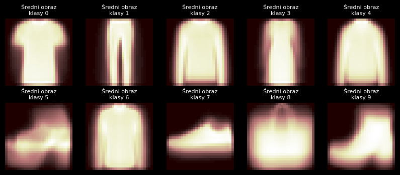

```python
mean_images = []
for label in range(10):
    class_data = x_train_full[y_train_full == label]
    mean_img = class_data.mean(axis=0)
    mean_images.append(mean_img)

plt.figure(figsize=(10, 4))
for i in range(10):
    plt.subplot(2, 5, i + 1)
    plt.imshow(mean_images[i], cmap='pink')
    plt.title(f"Średni obraz\nklasy {i}", fontsize=8)
    plt.axis('off')
plt.show()
```

Dla każdej z 10 klas obliczono „uśredniony” obraz - efekt to rozmyty kształt typowego przedstawiciela danej kategorii. Widać wyraźnie, że klasy mają charakterystyczne sylwetki, które powtarzają się w danych.

## Normalizacja pikseli

```python
x_train_full = x_train_full / 255.0
x_test       = x_test / 255.0

print("\n=== EDA: STATYSTYKI PO NORMALIZACJI (train full) ===")
print("Pixel min:", float(x_train_full.min()))
print("Pixel max:", float(x_train_full.max()))
print("Pixel mean:", float(x_train_full.mean()))
print("Pixel std:", float(x_train_full.std()))
```

```
=== EDA: STATYSTYKI PO NORMALIZACJI (train full) ===
Pixel min: 0.0
Pixel max: 1.0
Pixel mean: 0.2860405969887955
Pixel std: 0.35302424451492254
```

Obrazy przeskalowano z zakresu 0–255 do 0–1, dzieląc wartości pikseli przez 255. Po normalizacji średnia pikseli spadła do ok. 0.286, a odchylenie do 0.353. Dzięki temu sieć uczy się stabilniej, bo wejścia mają bardziej jednolity i przewidywalny zakres.

## Podział danych na zbiory treningowy, walidacyjny i testowy (70/15/15)

```python
X_tmp, X_test_final, y_tmp, y_test_final = train_test_split(
    x_train_full, y_train_full,
    test_size=0.15,
    random_state=BASE_SEED,
    stratify=y_train_full,
    shuffle=True
)

X_train, X_val, y_train, y_val = train_test_split(
    X_tmp, y_tmp,
    test_size=0.1764706, # test_size=15/(70+15)-to dokładnie 0.1764706 -> finalny podział 70/15/15
    random_state=BASE_SEED,
    stratify=y_tmp,
    shuffle=True
)

print("\n=== ROZMIARY ===")
print("Train:", X_train.shape, " Val:", X_val.shape, " Test:", X_test_final.shape)
```

```
=== ROZMIARY ===
Train: (41999, 28, 28)  Val: (9001, 28, 28)  Test: (9000, 28, 28)
```

Po podziale uzyskano: 41 999 obrazów treningowych, 9 001 walidacyjnych oraz 9 000 testowych, każdy o wymiarach 28×28 pikseli.

## Rozkład klas po podziale

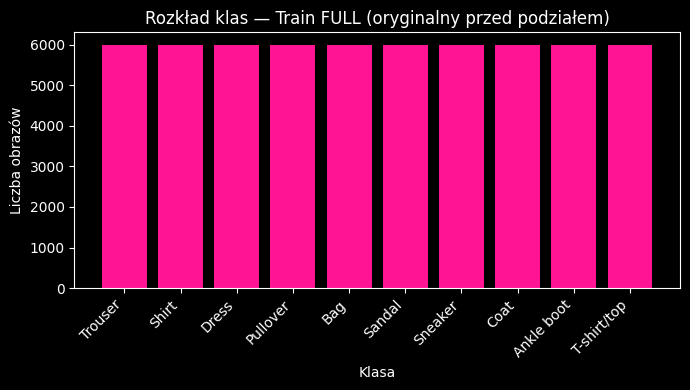

```python
class_names = [
    "T-shirt/top", "Trouser", "Pullover", "Dress", "Coat",
    "Sandal", "Shirt", "Sneaker", "Bag", "Ankle boot"
]

def plot_distribution(counter_dict, title):
    labels = list(counter_dict.keys())
    values = [counter_dict[k] for k in labels]

    plt.figure(figsize=(7, 4))
    plt.bar(labels, values, color="deeppink")
    plt.title(title)
    plt.xlabel("Klasa")
    plt.ylabel("Liczba obrazów")
    plt.xticks(labels, class_names, rotation=45, ha='right')
    plt.tight_layout()
    plt.show()

# Przed podziałem
plot_distribution(Counter(y_train_full), "Rozkład klas — Train FULL (oryginalny przed podziałem)")
```

Rozkład klas w oryginalnym zbiorze treningowym jest idealnie zbalansowany — każda z 10 klas zawiera 6000 obrazów. Oznacza to, że dane nie faworyzują żadnej kategorii, co ułatwia trenowanie modeli i zapobiega ich stronniczości wobec konkretnych klas.

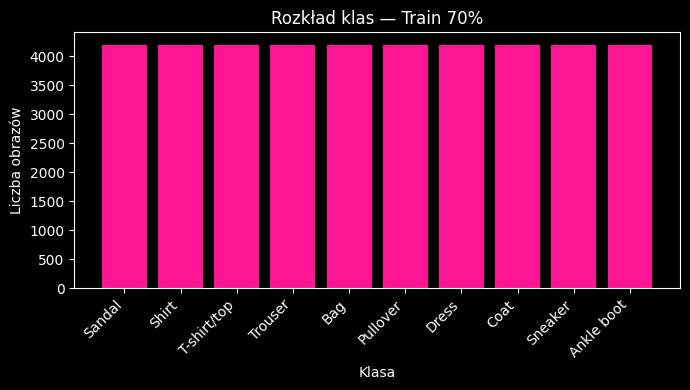

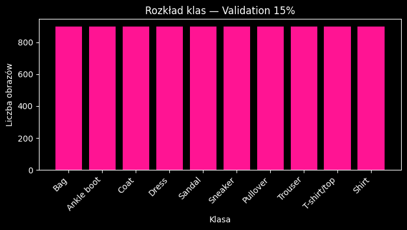

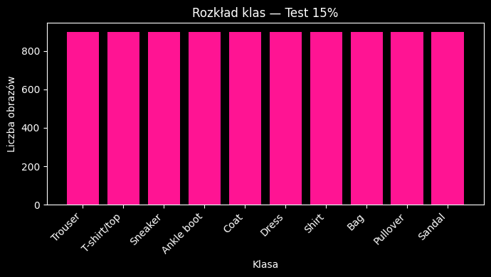

```python
# Po podziale 70/15/15
plot_distribution(Counter(y_train),      "Rozkład klas — Train 70%")
plot_distribution(Counter(y_val),        "Rozkład klas — Validation 15%")
plot_distribution(Counter(y_test_final), "Rozkład klas — Test 15%")
```

Po podziale 70/15/15 proporcje klas pozostały idealnie zbalansowane. Każdy zbiór - treningowy, walidacyjny i testowy — zawiera niemal identyczną liczbę przykładów dla każdej kategorii.

## Funkcje obliczania i podsumowania metryk

Funkcja `compute_metrics` liczy podstawowe metryki (accuracy, precision, recall, F1).

Funkcja `summarize_runs` zbiera wyniki z wielu powtórzeń treningu i dla każdej metryki (accuracy, precision, recall, F1) oblicza średnią, odchylenie standardowe oraz najlepszy uzyskany rezultat — osobno dla zbioru walidacyjnego i testowego. Dzięki temu można ocenić zarówno ogólną skuteczność modelu, jak i stabilność jego działania.

```python
def compute_metrics(y_true, y_pred):
    return {
        "accuracy":  accuracy_score(y_true, y_pred),
        "precision": precision_score(y_true, y_pred, average="macro", zero_division=0),
        "recall":    recall_score(y_true, y_pred, average="macro", zero_division=0),
        "f1":        f1_score(y_true, y_pred, average="macro", zero_division=0),
    }

def summarize_runs(run_metrics):
    out = {}
    for split in ["val", "test"]:
        out[split] = {}
        for k in ["accuracy", "precision", "recall", "f1"]:
            vals = [m[split][k] for m in run_metrics]
            out[split][k + "_mean"] = float(np.mean(vals))
            out[split][k + "_std"]  = float(np.std(vals))
            out[split][k + "_max"]  = float(np.max(vals))
    return out
```

## Perceptron (DeepMLP)

```python
x_train_flat = x_train_full.reshape(x_train_full.shape[0], -1)  # (60000, 784)
x_test_flat = x_test.reshape(x_test.shape[0], -1)                # (10000, 784)
n_classes = 10
y_train_onehot = np.eye(n_classes)[y_train_full]  # (60000, 10)
y_test_onehot = np.eye(n_classes)[y_test]          # (10000, 10)

X_tmp, X_test_final, y_tmp, y_test_final = train_test_split(
    x_train_flat, y_train_onehot,
    test_size=0.15,
    random_state=BASE_SEED,
    stratify=y_train_full,
    shuffle=True
)

X_train, X_val, y_train, y_val = train_test_split(
    X_tmp, y_tmp,
    test_size=0.1764706, # test_size=15/(70+15)-to dokładnie 0.1764706 -> finalny podział 70/15/15
    random_state=BASE_SEED,
    stratify=y_tmp,
    shuffle=True
)

data_dict = {
            'X_train': X_train,
            'y_train': y_train,
            'X_val': X_val,
            'y_val': y_val,
            'X_test': X_test_final,
            'y_test': y_test_final
        }


class_names = ['T-shirt/top', 'Trouser', 'Pullover', 'Dress', 'Coat',
                   'Sandal', 'Shirt', 'Sneaker', 'Bag', 'Ankle boot']
y_train_labels = np.argmax(data_dict['y_train'], axis=1)
unique, counts = np.unique(y_train_labels, return_counts=True)
for cls, count in zip(unique, counts):
    print(f"  {class_names[cls]:15s}: {count:5d} ({count/len(y_train_labels)*100:.1f}%)")

experiment = MLPExperiment(
    task_type='classification',
    split_variant='A',
    n_repeats=3,
    n_jobs=-1
)

results = experiment.run_full_experiment(
    data_dict=data_dict,
    use_parallel_random_search=True
    )

# Zapisanie wyników
experiment.save_results('fashion_mnist_mlp_results.json')
```

[output not shown]

```
5. Trenowanie najlepszego modelu...
  Parametry: layers=5, neurons=176, lr=0.025222, opt=SGD, act=tanh

================================================================================
PODSUMOWANIE WYNIKÓW
================================================================================

--- Model podstawowy ---
Train: accuracy=0.9207 (±0.0041)
Val  : accuracy=0.8892 (±0.0010)
Test : accuracy=0.8835 (±0.0016)

--- Najlepszy model (po optymalizacji) ---
Test: accuracy=0.8829 (±0.0017)

--- Porównanie z sklearn ---
         model  train_time  accuracy  precision  recall  f1_score
0   Custom MLP  113.552222    0.8838   0.883494  0.8838  0.883376
1  Sklearn MLP  127.693080    0.8758   0.875152  0.8758  0.875082

--- Top 3 konfiguracje (Random Search) ---
    n_hidden_layers  n_neurons  learning_rate optimizer activation  accuracy_mean
17                5        176       0.025222       SGD       tanh       0.892056
18                6        240       0.000263      Adam       tanh       0.891583
11                5        240       0.003867       SGD       relu       0.891194

Wyniki zapisane do: fashion_mnist_mlp_results.json
```

## CNN (Keras)

Dodano dodatkowy wymiar do danych obrazowych, przekształcając dane z kształtu (n, 28, 28) do (n, 28, 28, 1), co jest wymagane przez warstwy konwolucyjne sieci CNN w bibliotece Keras/TensorFlow. Wyniki pokazują, że zbiór treningowy zawiera 41 999 obrazów, zbiór walidacyjny 9 001 obrazów, a zbiór testowy 9 000 obrazów, wszystkie o wymiarach 28×28 pikseli.

```python
# CNN – dodanie kanału
X_train_cnn = X_train[..., None]
X_val_cnn   = X_val[..., None]
X_test_cnn  = X_test_final[..., None]

print("CNN shapes:", X_train_cnn.shape, X_val_cnn.shape, X_test_cnn.shape)
```

```
CNN shapes: (41999, 28, 28, 1) (9001, 28, 28, 1) (9000, 28, 28, 1)
```

Funkcja `build_cnn` tworzy konwolucyjną sieć neuronową (CNN) przy użyciu biblioteki Keras/TensorFlow do klasyfikacji obrazów na 10 klas. Model składa się z bloków konwolucyjnych, warstw Dense do klasyfikacji oraz warstwy Dropout zapobiegającej przeuczeniu. Funkcja umożliwia elastyczną konfigurację architektury sieci oraz wybór optymalizatora (Adam, SGD, RMSprop), a zastosowanie augmentacji danych zwiększa odporność modelu na różnice w orientacji i pozycji obrazów.

```python
data_aug = tf.keras.Sequential([
    layers.RandomRotation(0.05),
    layers.RandomTranslation(0.05, 0.05),
])

def build_cnn(conv_blocks=2,
              base_filters=32,
              dense_units=128,
              learning_rate=1e-3,
              optimizer_name="adam",
              momentum=0.9):

    #conv_blocks  – ile bloków Conv2D+BN+MaxPool
    #base_filters – liczba filtrów w pierwszym bloku (kolejne ×2)
    #dense_units  – liczba neuronów w warstwie gęstej

    model = models.Sequential()
    model.add(layers.Input(shape=(28, 28, 1)))

    filters = base_filters
    for b in range(conv_blocks):
        model.add(layers.Conv2D(filters, (3, 3), activation='relu', padding="same"))
        model.add(layers.BatchNormalization())
        model.add(layers.MaxPooling2D(2, 2))
        filters *= 2

    model.add(layers.Flatten())
    model.add(layers.Dense(dense_units, activation='relu'))
    model.add(layers.Dropout(0.5))
    model.add(layers.Dense(10, activation='softmax'))

    opt_name = optimizer_name.lower()
    if opt_name == "adam":
        optimizer = tf.keras.optimizers.Adam(learning_rate=learning_rate)
    elif opt_name == "sgd":
        optimizer = tf.keras.optimizers.SGD(learning_rate=learning_rate, momentum=momentum)
    elif opt_name == "rmsprop":
        optimizer = tf.keras.optimizers.RMSprop(learning_rate=learning_rate, momentum=momentum)
    else:
        raise ValueError("Nieznany optymalizator dla CNN!")

    model.compile(
        optimizer=optimizer,
        loss='sparse_categorical_crossentropy',
        metrics=['accuracy']
    )
    return model
```

Funkcja `train_cnn_once` przeprowadza pełny proces trenowania sieci CNN z zadanymi hiperparametrami. Ustawia losowy seed dla powtarzalności wyników, buduje model CNN, a następnie trenuje go z wykorzystaniem mechanizmu EarlyStopping, który przerywa trening gdy dokładność walidacyjna nie poprawia się przez 3 kolejne epoki i przywraca najlepsze wagi modelu.bPo zakończeniu treningu funkcja generuje predykcje dla zbiorów walidacyjnego i testowego, oblicza metryki jakości i zwraca wyniki.

```python
def train_cnn_once(seed_offset=0,
                   epochs=15,
                   batch_size=64,
                   conv_blocks=2,
                   base_filters=32,
                   dense_units=128,
                   lr=1e-3,
                   optimizer_name="adam",
                   momentum=0.9,
                   use_aug=True):

    tf.keras.utils.set_random_seed(BASE_SEED + seed_offset)
    cnn = build_cnn(
        conv_blocks=conv_blocks,
        base_filters=base_filters,
        dense_units=dense_units,
        learning_rate=lr,
        optimizer_name=optimizer_name,
        momentum=momentum
    )

    callbacks = [
        tf.keras.callbacks.EarlyStopping(
            monitor='val_accuracy',
            patience=3,
            restore_best_weights=True
        )
    ]

    if use_aug:
        def aug_map(x, y):
            return data_aug(x, training=True), y

        train_ds = (
            tf.data.Dataset.from_tensor_slices((X_train_cnn, y_train))
            .shuffle(8192, seed=BASE_SEED + seed_offset)
            .batch(batch_size)
            .map(aug_map)
            .prefetch(tf.data.AUTOTUNE)
        )

        val_ds = (
            tf.data.Dataset.from_tensor_slices((X_val_cnn, y_val))
            .batch(batch_size)
            .prefetch(tf.data.AUTOTUNE)
        )

        hist = cnn.fit(
            train_ds,
            epochs=epochs,
            validation_data=val_ds,
            verbose=0,
            callbacks=callbacks
        )
    else:
        hist = cnn.fit(
            X_train_cnn, y_train,
            epochs=epochs,
            batch_size=batch_size,
            validation_data=(X_val_cnn, y_val),
            verbose=0,
            callbacks=callbacks
        )

    # predykcje
    y_pred_val  = np.argmax(cnn.predict(X_val_cnn,  batch_size=256, verbose=0), axis=1)
    y_pred_test = np.argmax(cnn.predict(X_test_cnn, batch_size=256, verbose=0), axis=1)

    m_val  = compute_metrics(y_val,        y_pred_val)
    m_test = compute_metrics(y_test_final, y_pred_test)

    return {
        "val": m_val,
        "test": m_test,
        "history": hist.history,
        "model": cnn
    }
```

Funkcja `run_experiments_cnn` automatyzuje proces testowania wpływu wybranego hiperparametru na wydajność sieci CNN poprzez systematyczne przeprowadzanie eksperymentów. Dla każdej wartości testowanego parametru funkcja przeprowadza 5 niezależnych treningów, co pozwala ocenić stabilność i średnią wydajność modelu.

Funkcja wykorzystuje bazowe wartości hiperparametrów i modyfikuje tylko ten parametr, który jest aktualnie testowany, pozostawiając pozostałe bez zmian. Po zakończeniu wszystkich treningów dla danej wartości parametru, wyniki są agregowane przy użyciu funkcji `summarize_runs`, która oblicza średnie metryki i odchylenia standardowe.

```python
def run_experiments_cnn(param_name, param_values,
                        epochs=15,
                        base_conv_blocks=2,
                        base_filters=32,
                        base_dense_units=128,
                        base_lr=1e-3,
                        base_opt="adam",
                        base_momentum=0.9,
                        use_aug=True):

    results = {}

    for val in param_values:
        print("\n=================================================")
        print(f" [CNN] TEST PARAMETRU: {param_name} = {val}")
        print("=================================================")

        run_metrics = []

        for r in range(5):
            print(f"  -> [CNN] run {r+1}/5...")

            conv_blocks  = base_conv_blocks
            filters      = base_filters
            dense_units  = base_dense_units
            lr           = base_lr
            opt          = base_opt
            mom          = base_momentum

            if param_name == "conv_blocks":       # liczba warstw (bloków konwolucyjnych)
                conv_blocks = val
            elif param_name == "dense_units":     # liczba neuronów w FC
                dense_units = val
            elif param_name == "learning_rate":
                lr = val
            elif param_name == "optimizer":
                opt = val
            elif param_name == "momentum":
                mom = val

            run_metrics.append(
                train_cnn_once(
                    seed_offset=r,
                    epochs=epochs,
                    conv_blocks=conv_blocks,
                    base_filters=filters,
                    dense_units=dense_units,
                    lr=lr,
                    optimizer_name=opt,
                    momentum=mom,
                    use_aug=use_aug
                )
            )

        results[str(val)] = summarize_runs(run_metrics)

    fname = f"dobre_cnn_analysis_{param_name}.json"
    with open(fname, "w") as f:
        json.dump(results, f, indent=2)

    print(f"\n*** [CNN] Zapisano wyniki do {fname} ***\n")
    return results
```

Przeprowadzono analizę wpływu pięciu kluczowych hiperparametrów na wydajność sieci CNN: liczby bloków konwolucyjnych (1-4), liczby neuronów w warstwie Dense (64-512), współczynnika uczenia (learning rate od 1e-4 do 5e-3), typu optymalizatora (Adam, SGD, RMSprop) oraz wartości momentum (0.0-0.9). Każdy eksperyment testuje różne wartości danego parametru, wykonując dla każdej wartości 5 niezależnych treningów w celu uzyskania statystycznie wiarygodnych wyników.

```python
# liczba warstw (bloków konwolucyjnych)
conv_blocks_to_test = [1, 2, 3, 4]
results_cnn_blocks = run_experiments_cnn("conv_blocks", conv_blocks_to_test)

# liczba neuronów w warstwie gęstej
dense_units_to_test = [64, 128, 256, 512]
results_cnn_dense = run_experiments_cnn("dense_units", dense_units_to_test)

# learning rate
cnn_lr_to_test = [1e-4, 5e-4, 1e-3, 5e-3]
results_cnn_lr = run_experiments_cnn("learning_rate", cnn_lr_to_test)

# optymalizator
cnn_optimizers_to_test = ["adam", "sgd", "rmsprop", "sgd"]
results_cnn_opt = run_experiments_cnn("optimizer", cnn_optimizers_to_test)

# momentum (dla optymalizatorów, gdzie ma sens – zwłaszcza SGD/RMSProp)
cnn_momentum_to_test = [0.0, 0.3, 0.6, 0.9]
results_cnn_mom = run_experiments_cnn("momentum", cnn_momentum_to_test)

print("\n=== KONIEC ANALIZ CNN ===\n")
```

```
=================================================
 [CNN] TEST PARAMETRU: conv_blocks = 1
=================================================
  -> [CNN] run 1/5...
  -> [CNN] run 2/5...
  -> [CNN] run 3/5...
  -> [CNN] run 4/5...
  -> [CNN] run 5/5...

=================================================
 [CNN] TEST PARAMETRU: conv_blocks = 2
=================================================
  -> [CNN] run 1/5...
  -> [CNN] run 2/5...
  -> [CNN] run 3/5...
  -> [CNN] run 4/5...
  -> [CNN] run 5/5...

=================================================
 [CNN] TEST PARAMETRU: conv_blocks = 3
=================================================
  -> [CNN] run 1/5...
  -> [CNN] run 2/5...
  -> [CNN] run 3/5...
  -> [CNN] run 4/5...
  -> [CNN] run 5/5...

=================================================
 [CNN] TEST PARAMETRU: conv_blocks = 4
=================================================
  -> [CNN] run 1/5...
  -> [CNN] run 2/5...
  -> [CNN] run 3/5...
  -> [CNN] run 4/5...
  -> [CNN] run 5/5...

*** [CNN] Zapisano wyniki do dobre_cnn_analysis_conv_blocks.json ***


=================================================
```

[output cut: 141 more lines]

```
  -> [CNN] run 5/5...

=================================================
 [CNN] TEST PARAMETRU: momentum = 0.9
=================================================
  -> [CNN] run 1/5...
  -> [CNN] run 2/5...
  -> [CNN] run 3/5...
  -> [CNN] run 4/5...
  -> [CNN] run 5/5...

*** [CNN] Zapisano wyniki do dobre_cnn_analysis_momentum.json ***


=== KONIEC ANALIZ CNN ===
```

Poniżej wytrenowano model CNN dla parametrów o najlepszych wynikach: 2 bloki konwolucyjne, 512 neuronów w warstwie Dense, learning rate 0.001, optymalizator Adam z momentum 0.6.

```python
# train best CNN configuration
res = []
for r in range(5):
    print(f"  -> [CNN] run {r+1}/5...")

    conv_blocks  = 2
    filters      = 32
    dense_units  = 512
    lr           = 0.001
    opt          = "adam"
    mom          = 0.6


    res.append(train_cnn_once(
            seed_offset=r,
            epochs=15,
            conv_blocks=conv_blocks,
            base_filters=filters,
            dense_units=dense_units,
            lr=lr,
            optimizer_name=opt,
            momentum=mom,
            use_aug=True
        ))
```

```
  -> [CNN] run 1/5...
  -> [CNN] run 2/5...
  -> [CNN] run 3/5...
  -> [CNN] run 4/5...
  -> [CNN] run 5/5...
```

```python
res = summarize_runs(res)
```

Na samym końcu zapisano wyniki najlepszego CNN do pliku `best_analysis_cnn.json`.

```python
fname = f"best_analysis_cnn.json"
with open(fname, "w") as f:
    json.dump(res, f, indent=2)
```

## Analiza wyników

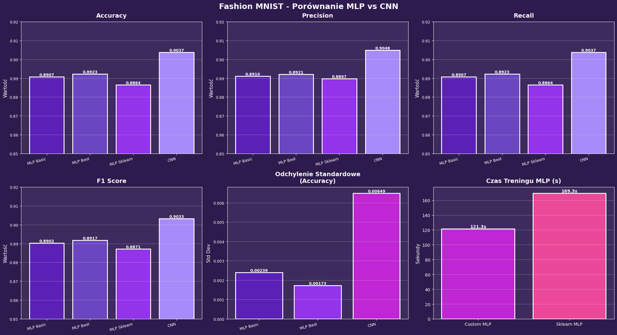

```python
# Wczytanie danych z wszystkich plików
with open('results/fashion_mnist_mlp_results2.json', 'r') as f:
    mlp_data = json.load(f)

with open('results/best_analysis_cnn.json', 'r') as f:
    cnn_data = json.load(f)

with open('results/dobre_cnn_analysis_learning_rate.json', 'r') as f:
    cnn_lr_data = json.load(f)

with open('results/dobre_cnn_analysis_conv_blocks.json', 'r') as f:
    cnn_blocks_data = json.load(f)

with open('results/dobre_cnn_analysis_dense_units.json', 'r') as f:
    cnn_dense_data = json.load(f)

with open('results/dobre_cnn_analysis_momentum.json', 'r') as f:
    cnn_momentum_data = json.load(f)

with open('results/dobre_cnn_analysis_optimizer.json', 'r') as f:
    cnn_optimizer_data = json.load(f)

# WYKRES 1: PORÓWNANIE MODELI
fig, axes = plt.subplots(2, 3, figsize=(20, 11))
fig.patch.set_facecolor('#2D1B4E')
for ax in axes.flat:
    ax.set_facecolor('#3D2B5E')

metrics = ['accuracy', 'precision', 'recall', 'f1_score']
metric_names = ['Accuracy', 'Precision', 'Recall', 'F1 Score']

# Dane dla porównania
mlp_basic_test = mlp_data['basic_model']['test']
mlp_best_test = mlp_data['best_model']
mlp_sklearn = mlp_data['sklearn_comparison']
cnn_test = cnn_data['test']

# Przygotowanie danych wszystkich modeli
models_data = {
    'MLP Basic': [
        mlp_basic_test['accuracy_mean'],
        mlp_basic_test['precision_mean'],
        mlp_basic_test['recall_mean'],
        mlp_basic_test['f1_score_mean']
    ],
    'MLP Best': [
        mlp_best_test['accuracy_mean'],
        mlp_best_test['precision_mean'],
        mlp_best_test['recall_mean'],
        mlp_best_test['f1_score_mean']
    ],
    'MLP Sklearn': [
        mlp_sklearn['accuracy']['1'],
        mlp_sklearn['precision']['1'],
        mlp_sklearn['recall']['1'],
        mlp_sklearn['f1_score']['1']
    ],
    'CNN': [
        cnn_test['accuracy_mean'],
        cnn_test['precision_mean'],
        cnn_test['recall_mean'],
        cnn_test['f1_mean']
    ]
}

# Wykresy słupkowe dla każdej metryki
for idx, (metric, name) in enumerate(zip(metrics[:4], metric_names)):
    ax = axes[idx // 3, idx % 3]
    values = [models_data[model][idx] for model in models_data.keys()]
    bars = ax.bar(models_data.keys(), values, color=GRADIENT[:4],
                   edgecolor='white', linewidth=2)
    ax.set_title(name, fontsize=14, fontweight='bold', color='white', pad=10)
    ax.set_ylabel('Wartość', fontsize=11, color='white')
    ax.tick_params(colors='white', labelsize=9)
    ax.grid(axis='y', alpha=0.3, color='white')
    ax.set_ylim([0.85, 0.92])
    plt.setp(ax.xaxis.get_majorticklabels(), rotation=15, ha='right')

    for bar in bars:
        height = bar.get_height()
        ax.text(bar.get_x() + bar.get_width()/2., height,
                f'{height:.4f}', ha='center', va='bottom',
                color='white', fontsize=9, fontweight='bold')

# Porównanie odchyleń standardowych
ax = axes[1, 1]
std_data = {
    'MLP Basic': mlp_basic_test['accuracy_std'],
    'MLP Best': mlp_best_test['accuracy_std'],
    'CNN': cnn_test['accuracy_std']
}
bars = ax.bar(std_data.keys(), std_data.values(),
              color=[GRADIENT[0], GRADIENT[2], GRADIENT[4]],
              edgecolor='white', linewidth=2)
ax.set_title('Odchylenie Standardowe\n(Accuracy)', fontsize=14,
             fontweight='bold', color='white', pad=10)
ax.set_ylabel('Std Dev', fontsize=11, color='white')
ax.tick_params(colors='white', labelsize=9)
ax.grid(axis='y', alpha=0.3, color='white')
plt.setp(ax.xaxis.get_majorticklabels(), rotation=15, ha='right')

for bar in bars:
    height = bar.get_height()
    ax.text(bar.get_x() + bar.get_width()/2., height,
            f'{height:.5f}', ha='center', va='bottom',
            color='white', fontsize=9, fontweight='bold')

# Porównanie czasu treningu
ax = axes[1, 2]
train_times = [mlp_sklearn['train_time']['0'], mlp_sklearn['train_time']['1']]
bars = ax.bar(['Custom MLP', 'Sklearn MLP'], train_times,
               color=[COLORS['accent'], COLORS['pink']],
               edgecolor='white', linewidth=2)
ax.set_title('Czas Treningu MLP (s)', fontsize=14,
             fontweight='bold', color='white', pad=10)
ax.set_ylabel('Sekundy', fontsize=11, color='white')
ax.tick_params(colors='white')
ax.grid(axis='y', alpha=0.3, color='white')

for bar in bars:
    height = bar.get_height()
    ax.text(bar.get_x() + bar.get_width()/2., height,
            f'{height:.1f}s', ha='center', va='bottom',
            color='white', fontsize=10, fontweight='bold')

plt.suptitle('Fashion MNIST - Porównanie MLP vs CNN',
             fontsize=18, fontweight='bold', color='white', y=0.98)
plt.tight_layout()
plt.show()
```

-Wykres **Accuracy** pokazuje, że wszystkie warianty MLP osiągają bardzo podobną dokładność na poziomie ok.0.89, przy czym najlepszy wynik daje wariant „MLP Best” (0.8923), a najniższy - MLP Sklearn (0.8864). Jednak CNN wyraźnie odstaje na plus, osiągając 0.9037, co potwierdza, że sieci konwolucyjne znacznie lepiej wykorzystują strukturę obrazu niż perceptrony.

-**Precision** - Wszystkie warianty MLP osiągają precision na poziomie ok.0.89, z minimalnymi różnicami między wersjami (ponownie najlepiej wypada MLP Best – 0.8921, najgorzej MLP Sklearn – 0.8897). Jednak CNN znów wyraźnie dominuje, osiągając 0.9048, co oznacza, że znacznie lepiej unika błędnej klasyfikacji między podobnymi kategoriami ubrań.

-Wyniki **recall i F1 score** dla wszystkich wariantów MLP pozostają bardzo zbliżone, z lekką przewagą modelu „MLP Best” (0.8923). Wersja sklearn wypada najsłabiej w obu przypadkach. CNN ponownie wypada najlepiej, osiągając 0.9037 oraz 0.9033, co oznacza, że skuteczniej odnajduje poprawne przykłady każdej klasy, szczególnie tych trudniejszych w przypadku recall.

-**Odchylenie standardowe - Accuracy** - MLP charakteryzuje się bardzo niską zmiennością wyników: podstawowy wariant ma odchylenie 0.00239, a najlepszy — jeszcze niższe (0.00173). Oznacza to stabilne, powtarzalne działanie. CNN ma wyraźnie wyższą wariancję (0.00649), czyli jego accuracy między powtórzeniami bardziej się waha. Mimo to pozostaje dokładniejszy średnio, choć mniej przewidywalny.

-**Czas treningu MLP** - Customowy MLP trenował się wyraźnie szybciej (121.3 s) niż implementacja z biblioteki sklearn (169.3 s). Oznacza to, że własna implementacja ma mniejszy narzut obliczeniowy i efektywniej wykorzystuje zasoby, co jest dużą zaletą przy bardzo zbliżonych rezultatach jakościowych obu modeli.

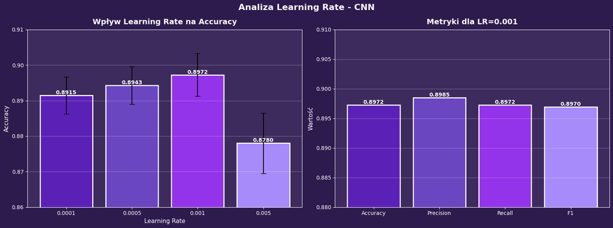

```python
# WYKRES 2: ANALIZA LEARNING RATE CNN
fig, axes = plt.subplots(1, 2, figsize=(16, 6))
fig.patch.set_facecolor('#2D1B4E')
for ax in axes.flat:
    ax.set_facecolor('#3D2B5E')

learning_rates = ['0.0001', '0.0005', '0.001', '0.005']
lr_accuracies = [cnn_lr_data[lr]['test']['accuracy_mean'] for lr in learning_rates]
lr_stds = [cnn_lr_data[lr]['test']['accuracy_std'] for lr in learning_rates]

# Wykres 1: Accuracy vs Learning Rate
ax = axes[0]
bars = ax.bar(learning_rates, lr_accuracies, color=GRADIENT[:4],
              edgecolor='white', linewidth=2, yerr=lr_stds, capsize=5)
ax.set_title('Wpływ Learning Rate na Accuracy', fontsize=14,
             fontweight='bold', color='white', pad=10)
ax.set_xlabel('Learning Rate', fontsize=11, color='white')
ax.set_ylabel('Accuracy', fontsize=11, color='white')
ax.tick_params(colors='white')
ax.grid(axis='y', alpha=0.3, color='white')
ax.set_ylim([0.86, 0.91])

for bar, acc in zip(bars, lr_accuracies):
    height = bar.get_height()
    ax.text(bar.get_x() + bar.get_width()/2., height,
            f'{acc:.4f}', ha='center', va='bottom',
            color='white', fontsize=10, fontweight='bold')

# Wykres 2: Wszystkie metryki dla najlepszego LR
ax = axes[1]
best_lr = '0.001'
metrics_lr = ['accuracy_mean', 'precision_mean', 'recall_mean', 'f1_mean']
metric_names_lr = ['Accuracy', 'Precision', 'Recall', 'F1']
values_lr = [cnn_lr_data[best_lr]['test'][m] for m in metrics_lr]

bars = ax.bar(metric_names_lr, values_lr, color=GRADIENT[:4],
              edgecolor='white', linewidth=2)
ax.set_title(f'Metryki dla LR={best_lr}', fontsize=14,
             fontweight='bold', color='white', pad=10)
ax.set_ylabel('Wartość', fontsize=11, color='white')
ax.tick_params(colors='white')
ax.grid(axis='y', alpha=0.3, color='white')
ax.set_ylim([0.88, 0.91])

for bar, val in zip(bars, values_lr):
    height = bar.get_height()
    ax.text(bar.get_x() + bar.get_width()/2., height,
            f'{val:.4f}', ha='center', va='bottom',
            color='white', fontsize=10, fontweight='bold')

plt.suptitle('Analiza Learning Rate - CNN',
             fontsize=16, fontweight='bold', color='white', y=0.98)
plt.tight_layout()
plt.show()
```

Analiza wpływu learning rate pokazała, że wartość tego parametru ma istotny wpływ na skuteczność sieci konwolucyjnej. Najniższe accuracy uzyskano przy zbyt dużym LR=0.005 (0.8780), co wskazuje na niestabilne uczenie. Bardzo niski LR=0.0001 dał poprawny, lecz przeciętny wynik (0.8915), a umiarkowany LR=0.0005 poprawił skuteczność do 0.8943.

Najlepsze rezultaty osiągnięto przy LR=0.001 (0.8972), co czyni go optymalnym wyborem. Dla tej wartości wszystkie metryki (accuracy, precision, recall i F1) utrzymują się na bardzo zbliżonym i wysokim poziomie około 0.897–0.899, potwierdzając stabilne i zrównoważone działanie modelu.

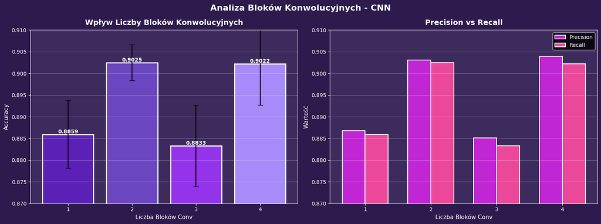

```python
# WYKRES 3: ANALIZA CONV BLOCKS
fig, axes = plt.subplots(1, 2, figsize=(16, 6))
fig.patch.set_facecolor('#2D1B4E')
for ax in axes.flat:
    ax.set_facecolor('#3D2B5E')

conv_blocks = ['1', '2', '3', '4']
block_accuracies = [cnn_blocks_data[b]['test']['accuracy_mean'] for b in conv_blocks]
block_stds = [cnn_blocks_data[b]['test']['accuracy_std'] for b in conv_blocks]

# Wykres 1: Accuracy vs Conv Blocks
ax = axes[0]
bars = ax.bar(conv_blocks, block_accuracies, color=GRADIENT[:4],
              edgecolor='white', linewidth=2, yerr=block_stds, capsize=5)
ax.set_title('Wpływ Liczby Bloków Konwolucyjnych', fontsize=14,
             fontweight='bold', color='white', pad=10)
ax.set_xlabel('Liczba Bloków Conv', fontsize=11, color='white')
ax.set_ylabel('Accuracy', fontsize=11, color='white')
ax.tick_params(colors='white')
ax.grid(axis='y', alpha=0.3, color='white')
ax.set_ylim([0.87, 0.91])

for bar, acc in zip(bars, block_accuracies):
    height = bar.get_height()
    ax.text(bar.get_x() + bar.get_width()/2., height,
            f'{acc:.4f}', ha='center', va='bottom',
            color='white', fontsize=10, fontweight='bold')

# Wykres 2: Porównanie Precision vs Recall
ax = axes[1]
x = np.arange(len(conv_blocks))
width = 0.35

precisions = [cnn_blocks_data[b]['test']['precision_mean'] for b in conv_blocks]
recalls = [cnn_blocks_data[b]['test']['recall_mean'] for b in conv_blocks]

bars1 = ax.bar(x - width/2, precisions, width, label='Precision',
               color=COLORS['accent'], edgecolor='white', linewidth=1.5)
bars2 = ax.bar(x + width/2, recalls, width, label='Recall',
               color=COLORS['pink'], edgecolor='white', linewidth=1.5)

ax.set_title('Precision vs Recall', fontsize=14,
             fontweight='bold', color='white', pad=10)
ax.set_xlabel('Liczba Bloków Conv', fontsize=11, color='white')
ax.set_ylabel('Wartość', fontsize=11, color='white')
ax.set_xticks(x)
ax.set_xticklabels(conv_blocks)
ax.tick_params(colors='white')
ax.legend(fontsize=10)
ax.grid(axis='y', alpha=0.3, color='white')
ax.set_ylim([0.87, 0.91])

plt.suptitle('Analiza Bloków Konwolucyjnych - CNN',
             fontsize=16, fontweight='bold', color='white', y=0.98)
plt.tight_layout()
plt.show()
```

Analiza pokazała, że liczba bloków konwolucyjnych wpływa na skuteczność modelu. Sieć z 1 blokiem uzyskała accuracy 0.8859, co wskazuje, że pojedynczy blok jest niewystarczający do uchwycenia wszystkich istotnych cech obrazu.

Najsłabsze wyniki zanotowała konfiguracja z 3 blokami (0.8833), prawdopodobnie z powodu zbyt dużej złożoności względem danych. Dodanie drugiego bloku wyraźnie poprawiło jakość modelu i dało najlepszy rezultat w całym zestawie (0.9025), natomiast sieć z 4 blokami również osiągnęła bardzo wysoki wynik (0.9022), zbliżony do modelu 2-blokowego.

Dodatkowe metryki precision i recall potwierdzają ten trend: najlepsze i najbardziej zrównoważone wartości uzyskano dla 2 oraz 4 bloków konwolucyjnych, natomiast konfiguracja 3-blokowa wypada najsłabiej.

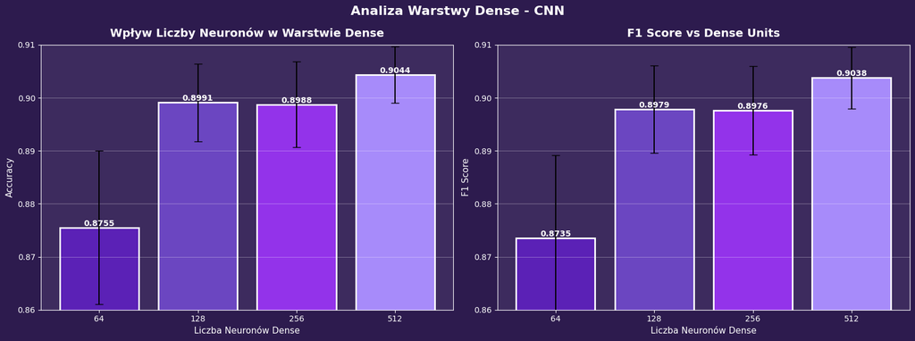

```python
# WYKRES 4: ANALIZA DENSE UNITS
fig, axes = plt.subplots(1, 2, figsize=(16, 6))
fig.patch.set_facecolor('#2D1B4E')
for ax in axes.flat:
    ax.set_facecolor('#3D2B5E')

dense_units = ['64', '128', '256', '512']
dense_accuracies = [cnn_dense_data[d]['test']['accuracy_mean'] for d in dense_units]
dense_stds = [cnn_dense_data[d]['test']['accuracy_std'] for d in dense_units]

# Wykres 1: Accuracy vs Dense Units
ax = axes[0]
bars = ax.bar(dense_units, dense_accuracies, color=GRADIENT[:4],
              edgecolor='white', linewidth=2, yerr=dense_stds, capsize=5)
ax.set_title('Wpływ Liczby Neuronów w Warstwie Dense', fontsize=14,
             fontweight='bold', color='white', pad=10)
ax.set_xlabel('Liczba Neuronów Dense', fontsize=11, color='white')
ax.set_ylabel('Accuracy', fontsize=11, color='white')
ax.tick_params(colors='white')
ax.grid(axis='y', alpha=0.3, color='white')
ax.set_ylim([0.86, 0.91])

for bar, acc in zip(bars, dense_accuracies):
    height = bar.get_height()
    ax.text(bar.get_x() + bar.get_width()/2., height,
            f'{acc:.4f}', ha='center', va='bottom',
            color='white', fontsize=10, fontweight='bold')

# Wykres 2: F1 Score vs Dense Units
ax = axes[1]
dense_f1 = [cnn_dense_data[d]['test']['f1_mean'] for d in dense_units]
dense_f1_std = [cnn_dense_data[d]['test']['f1_std'] for d in dense_units]

bars = ax.bar(dense_units, dense_f1, color=GRADIENT[:4],
              edgecolor='white', linewidth=2, yerr=dense_f1_std, capsize=5)
ax.set_title('F1 Score vs Dense Units', fontsize=14,
             fontweight='bold', color='white', pad=10)
ax.set_xlabel('Liczba Neuronów Dense', fontsize=11, color='white')
ax.set_ylabel('F1 Score', fontsize=11, color='white')
ax.tick_params(colors='white')
ax.grid(axis='y', alpha=0.3, color='white')
ax.set_ylim([0.86, 0.91])

for bar, f1 in zip(bars, dense_f1):
    height = bar.get_height()
    ax.text(bar.get_x() + bar.get_width()/2., height,
            f'{f1:.4f}', ha='center', va='bottom',
            color='white', fontsize=10, fontweight='bold')

plt.suptitle('Analiza Warstwy Dense - CNN',
             fontsize=16, fontweight='bold', color='white', y=0.98)
plt.tight_layout()
plt.show()
```

Analiza pokazała, że liczba neuronów w końcowej warstwie Dense ma istotny wpływ na jakość modelu. Najsłabszy wynik uzyskano przy 64 neuronach (accuracy 0.8755, F1 = 0.8735), co sugeruje zbyt małą pojemność tej warstwy i ograniczoną zdolność do uogólniania. Zwiększenie liczby neuronów do 128 znacząco poprawiło skuteczność, a 256 neuronów dało bardzo podobny rezultat, co wskazuje na stabilizację jakości w tym zakresie. Najlepsze wyniki osiągnięto przy 512 neuronach — accuracy 0.9044 oraz F1 = 0.9038 — co sugeruje, że większa liczba neuronów pozwala modelowi uchwycić bardziej złożone zależności, jednocześnie nie prowadząc do przetrenowania.

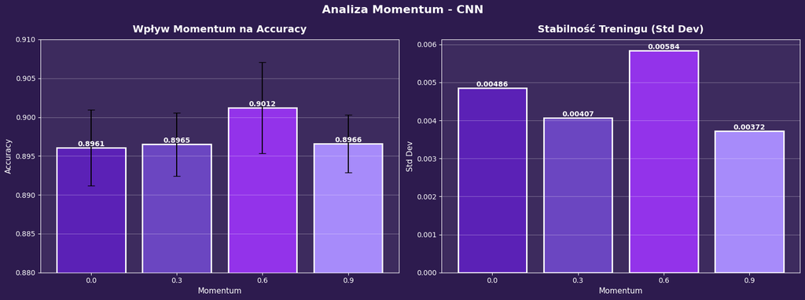

```python
# WYKRES 5: ANALIZA MOMENTUM
fig, axes = plt.subplots(1, 2, figsize=(16, 6))
fig.patch.set_facecolor('#2D1B4E')
for ax in axes.flat:
    ax.set_facecolor('#3D2B5E')

momentum_vals = ['0.0', '0.3', '0.6', '0.9']
momentum_accuracies = [cnn_momentum_data[m]['test']['accuracy_mean'] for m in momentum_vals]
momentum_stds = [cnn_momentum_data[m]['test']['accuracy_std'] for m in momentum_vals]

# Wykres 1: Accuracy vs Momentum
ax = axes[0]
bars = ax.bar(momentum_vals, momentum_accuracies, color=GRADIENT[:4],
              edgecolor='white', linewidth=2, yerr=momentum_stds, capsize=5)
ax.set_title('Wpływ Momentum na Accuracy', fontsize=14,
             fontweight='bold', color='white', pad=10)
ax.set_xlabel('Momentum', fontsize=11, color='white')
ax.set_ylabel('Accuracy', fontsize=11, color='white')
ax.tick_params(colors='white')
ax.grid(axis='y', alpha=0.3, color='white')
ax.set_ylim([0.88, 0.91])

for bar, acc in zip(bars, momentum_accuracies):
    height = bar.get_height()
    ax.text(bar.get_x() + bar.get_width()/2., height,
            f'{acc:.4f}', ha='center', va='bottom',
            color='white', fontsize=10, fontweight='bold')

# Wykres 2: Porównanie stabilności (Std Dev)
ax = axes[1]
bars = ax.bar(momentum_vals, momentum_stds, color=GRADIENT[:4],
              edgecolor='white', linewidth=2)
ax.set_title('Stabilność Treningu (Std Dev)', fontsize=14,
             fontweight='bold', color='white', pad=10)
ax.set_xlabel('Momentum', fontsize=11, color='white')
ax.set_ylabel('Std Dev', fontsize=11, color='white')
ax.tick_params(colors='white')
ax.grid(axis='y', alpha=0.3, color='white')

for bar, std in zip(bars, momentum_stds):
    height = bar.get_height()
    ax.text(bar.get_x() + bar.get_width()/2., height,
            f'{std:.5f}', ha='center', va='bottom',
            color='white', fontsize=10, fontweight='bold')

plt.suptitle('Analiza Momentum - CNN',
             fontsize=16, fontweight='bold', color='white', y=0.98)
plt.tight_layout()
plt.show()
```